# Statistics Anxiety and Academic Attainment

Emma Crawford, Alice Miller, Leah Cookson, Alexandra Anderson

2026-11-19

## Introduction

Statistics anxiety may present a barrier to students’ academic attainment, although its relationship with mathematics anxiety remains unclear. Using the SMARVUS dataset (Terry et al., 2023), which contains responses from 12,570 students across 35 countries, we investigate the association between statistics anxiety and statistics module attainment, accounting for differences between participating surveys. We also explore whether statistics anxiety provides additional explanatory power beyond mathematics anxiety and assess the robustness of our findings to alternative analytical decisions.

## Summary of the Analysis Approach

We used individual-level SMARVUS data, standardising academic attainment across grading systems and constructing anxiety scores from established questionnaires. Linear regression with survey fixed effects and CR2 cluster-robust confidence intervals was used to investigate the association between statistics anxiety and attainment. Model diagnostics and sensitivity analyses assessed the robustness of the findings to alternative analytical decisions. As a secondary analysis, we compared statistics and mathematics anxiety using correlations, separate and joint regression models, and changes in explained variance to investigate whether statistics anxiety provided additional explanatory information.

## Details of the Analysis

### Data Preparation and Participant Exclusions

#### Initial Inspection and Grade Availability

The SMARVUS dataset contained 12,570 observations and 788 variables. We checked for identical rows and missing or duplicated participant identifiers (‘unique_id’); none were found. Missing responses were investigated with reference to the variables required for this analysis rather than excluding participants with missing entries in other places of the questionnaire. Statistics attainment was recorded in ‘grade’, with 1820 participants having a grade entry other than ‘NA’ or ‘Not Available’.

#### Standardising Attainment Across Institutions

Reported grades were recorded differently across the participating surveys. This included different numerical scales, letter grades and ordinal categories. We examined each institution’s lowest and highest documented grades before we constructed a comparable attainment variable. Supported numerical marks (0–100, 0–20, 0–10 and 1–10) were linearly rescaled to a common 0–100 range:

$$\text{Scaled grade} = 100\,\frac{\text{Observed grade} - \text{Lowest
possible grade}}{\text{Highest possible grade} - \text{Lowest possible
grade}}.$$

To keep observations that used letter grades, we used the midpoint of the applicable institution-specific percentage band as an estimated numerical mark. Grade categories that could not be converted reasonably or defensibly, including the 1–5 ordinal systems, ambiguous entries and values outside continuous-attainment datasets were excluded. This left us with 1362 converted numerical grades and 320 estimated letter grades (1682 observations in total). Grade-band midpoints are approximations, and it is important to note that converting to a common range does not remove the differences in grading standards across different institutions.

#### Attention Checks and Exclusion Criteria

We assessed response quality using the six attention check items and the ‘attention_amnesty’ response. Participants were excluded if they answered at least one administered check incorrectly or explicitly selected ‘No’ to the amnesty question. Missing check or amnesty responses were not interpreted as failures as the questions were not necessarily recorded for every survey. Under these rules, 1542 participants remained after attainment and quality screening. Anxiety-scale completeness criteria are applied in the next section.

The participant counts at each stage are summarised in the table below. Of the 1542 kept observations, 165 had no recorded attention check answers and 70 had a missing amnesty response. Because estimated letter grades are approximations, we also test whether excluding them affects our findings in the sensitivity analyses below.

| Stage | N | Excluded |
| --- | --- | --- |
| Original dataset | 12570 | NA |
| Non-missing grade entries | 1820 | 10750 |
| Usable standardised attainment | 1682 | 138 |
| After attention amnesty | 1655 | 27 |
| After attention checks | 1542 | 113 |

### Anxiety measures and scoring

The next step is to construct reliable anxiety scores from the questionnaire results.The SMARVUS survey includes four anxiety scales, two measuring statistics anxiety and two measuring mathematics anxiety. The original instruments are the Statistics Anxiety Rating Scale (STARS; Q7.1_1–Q7.1_23, 23 questions) and the Revised Mathematics Anxiety Rating Scale (RMARS; Q8.2_1–Q8.2_24, 24 questions). Because these two scales differ slightly, STARS includes questions on fear of asking for help, whereas RMARS does not. The SMARVUS authors also created modified versions of each scale that swap the subject wording: a mathematics version of STARS (STARS-M; Q8.1_1–Q8.1_20, 20 questions) and a statistics version of RMARS (RMARS-S; Q7.2_1–Q7.2_23, 23 questions). Including all four scales allows us to test whether statistics anxiety and mathematics anxiety are genuinely distinct constructs or are testing the same thing.

All items across the four scales are rated on a 1–5 scale, where 5 represents a high anxiety and 1 a low anxiety. Two of the attention-check items used in the previous section sit directly at the end of the STARS and STARS-M blocks (Q7.1_24 and Q8.1_21), so these were excluded when selecting the scale items.

#### Investigating Missing Entries

Before calculating any scores, we checked that all observed responses fell within the expected 1–5 range and inspected how many NAs are present on each scale.

NA’s and observed response range for each anxiety scale.

| Scale | Number of Questions | Complete sets of answers | Partially Missing | All Missing | Min | Max |
| --- | --- | --- | --- | --- | --- | --- |
| STARS | 23 | 1521 | 7 | 14 | 1 | 5 |
| RMARS-S | 23 | 1445 | 83 | 14 | 1 | 5 |
| STARS-M | 20 | 1519 | 6 | 17 | 1 | 5 |
| RMARS | 24 | 1445 | 82 | 15 | 1 | 5 |

As shown in the table above, every recorded response across all four scales lay as expected between 1 and 5. Majority of the results are complete, with only 14 to 17 participants skipping an entire scale. However, a clear split appeared in partial missingness: while STARS and STARS-M had only 7 and 6 partially missing respondents respectively, RMARS-S had 83 and RMARS had 82. To see whether those participants were skipping just one or two questions or leaving large chunks blank, we plotted the number of missing items among partially missing respondents only.

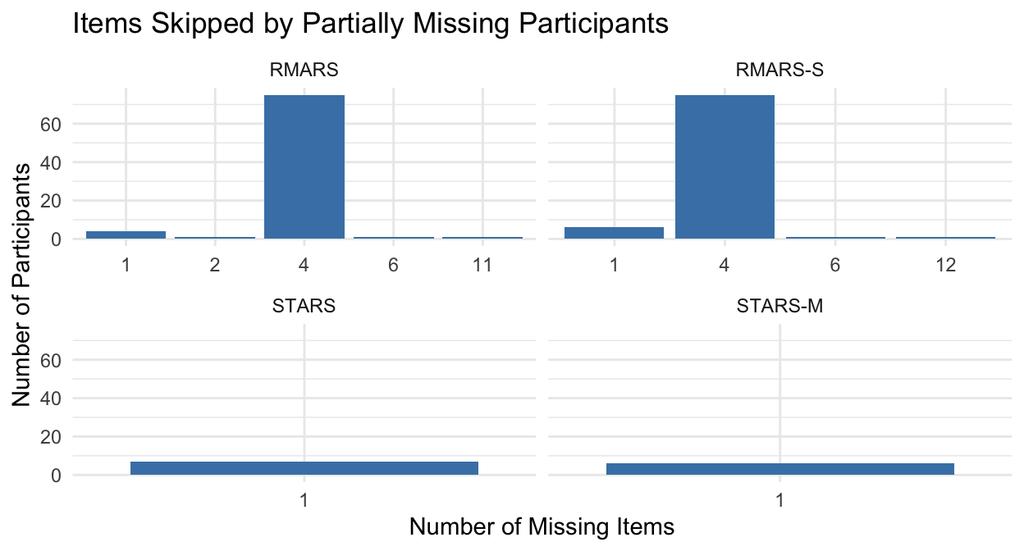

The plot revealed two very different patterns. On STARS and STARS-M, every single partially missing participant hadn’t answered only 1 question, and checking by question number and institution confirmed that these were spread acorss question number and across multiple universities rather than concentrated in one place. In contrast, RMARS-S and RMARS both showed a large spike at exactly 4 missing items.

Further investigation by institution showed that this spike came from Erasmus University Rotterdam ($n = 77$), where 75 students were missing four items on RMARS-S and 75 were missing four items on RMARS. Checking missingness by question confirmed that not a single participant from Erasmus University Rotterdam had recorded responses for the final four items of either scale. This indicates that these questions were omitted from the Erasmus University Rotterdam version of the survey.

Because the four scales differ in length (20, 23, and 24), we scored each scale using the mean item score rather than a raw sum score. Taking the mean places all four anxiety measures on the same 1–5 scale so they can be compared directly, and prevents students with a small number of omitted items from receiving artificially low scores.

To handle partial missingness, we applied an 80% completion threshold (requiring at least 19 of 23 items on STARS and RMARS-S, 16 of 20 on STARS-M, and 20 of 24 on RMARS) and retained participants who met this threshold on all four scales so that the primary and secondary analyses use the same sample. This rule retains the Erasmus University Rotterdam cohort (who completed 82.6% of RMARS-S and 83.3% of RMARS) as well as the handful of students who skipped one or two items, while still excluding anyone who missed an entire scale or large blocks of questions. As a stricter alternative, requiring 100% item completion avoids making any assumptions about omitted questions but excludes participants for items they were never administered. We therefore also constructed a complete-case scored dataset to test whether this scoring choice affects our results in the sensitivity analyses.

Below, we calculate the anxiety scores and descriptive statistics.

Applying the 80% threshold across all four scales excludes 33 participants, leaving 1509 participants for the primary analysis (compared with 1412 under complete-case scoring, which excludes 130 participants). The descriptive statistics for each scale under the 80% rule are summarised below.

Descriptive statistics for the four anxiety scales under the 80% completion threshold (evaluated on N = 1,542).

| Scale | Valid (N) | Missing (N) | Missing (%) | Mean | SD | Min | Max |
| --- | --- | --- | --- | --- | --- | --- | --- |
| RMARS | 1525 | 17 | 1.1 | 3.03 | 0.80 | 1 | 5 |
| RMARS-S | 1526 | 16 | 1.0 | 3.13 | 0.84 | 1 | 5 |
| STARS | 1528 | 14 | 0.9 | 2.95 | 0.80 | 1 | 5 |
| STARS-M | 1525 | 17 | 1.1 | 2.96 | 0.82 | 1 | 5 |

To check the shape of the four anxiety measures—and look for any skewness, outliers, or clustering at the extremes of the 1–5 scale, we plotted histograms of the scored variables.

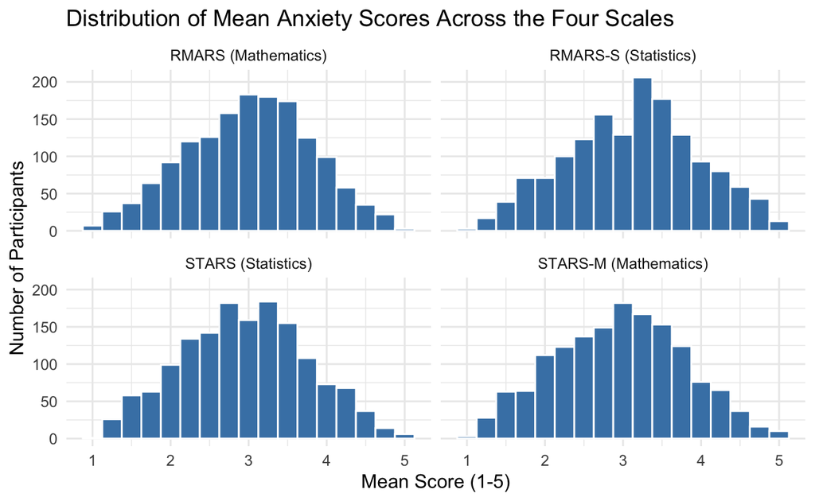

All four anxiety scales show roughly symmetric, bell-shaped distributions centered near the midpoint of 3, with RMARS-S centered slightly higher than the other three measures. Scores are well spread across the 1–5 range with no obvious skewness, outliers, or clustering at the floor or ceiling of the scale. This indicates that all four composite scores are well-behaved and suitable for analysis.

#### Scoring Limitations

There are two main limitations when interpreting these anxiety scores. Under the 80% completion threshold, scores for Erasmus University Rotterdam on RMARS-S and RMARS are averaged over 19 and 20 questions rather than 23 and 24. Averaging over answered questions assumes that the omitted questions would have had the same average anxiety rating as the rest of the scale. If those four answers tended to reflect higher or lower anxiety, scores for that cohort could be slightly shifted. Using fewer questions can also slightly reduce measurement precision. As shown in the sensitivity analyses below, however, repeating the primary regression on the complete-case sample produces an almost identical estimate.

The other limitation is that averaging all items on a questionnaire into a single overall score treats each type of anxiety as one uniform trait. Both STARS and RMARS cover distinct fears such as test anxiety and fear of asking for help, and combining them into one mean could hide differences in how each aspect relates to attainment.

### Statistical analysis and effect size

### Analytical approach

We examined the relationship between statistics anxiety and academic attainment using Pearson’s correlation and linear regression. Statistics anxiety was measured using the mean Statistics Anxiety Rating Scale (STARS) score, ranging from 1 (low anxiety) to 5 (high anxiety), while attainment was measured using grades converted to a common 0–100 scale. The primary sample comprised 1,509 participants across 20 surveys who met the 80% completion threshold for all four anxiety measures, allowing subsequent comparisons with mathematics anxiety using a consistent sample.

Pearson’s correlation was used to quantify the unadjusted linear association. However, differences in grading standards, educational contexts and student populations could introduce systematic variation between surveys. We therefore fitted an initial unadjusted regression before introducing survey fixed effects. This allows each survey to have a different baseline attainment level while estimating a common within-survey association between STARS and attainment.

The regression coefficient quantifies the estimated attainment-point difference associated with a one-point increase in STARS, while partial $R^2$ measures the additional explanatory contribution of statistics anxiety beyond survey differences. Model diagnostics and sensitivity analyses were used to assess the reliability of our findings.

### Association between statistics anxiety and attainment

The unadjusted relationship between statistics anxiety and academic attainment was negative but relatively weak (Pearson’s $r=-0.166$, 95% CI $[-0.215,-0.117]$, $p<0.001$). As illustrated in Figure 1, higher anxiety scores were generally associated with lower grades, although substantial variation in attainment remained at each anxiety level. The correlation corresponded to $r^2=0.028$, indicating that approximately 2.8% of attainment variation was accounted for by the unadjusted linear relationship.

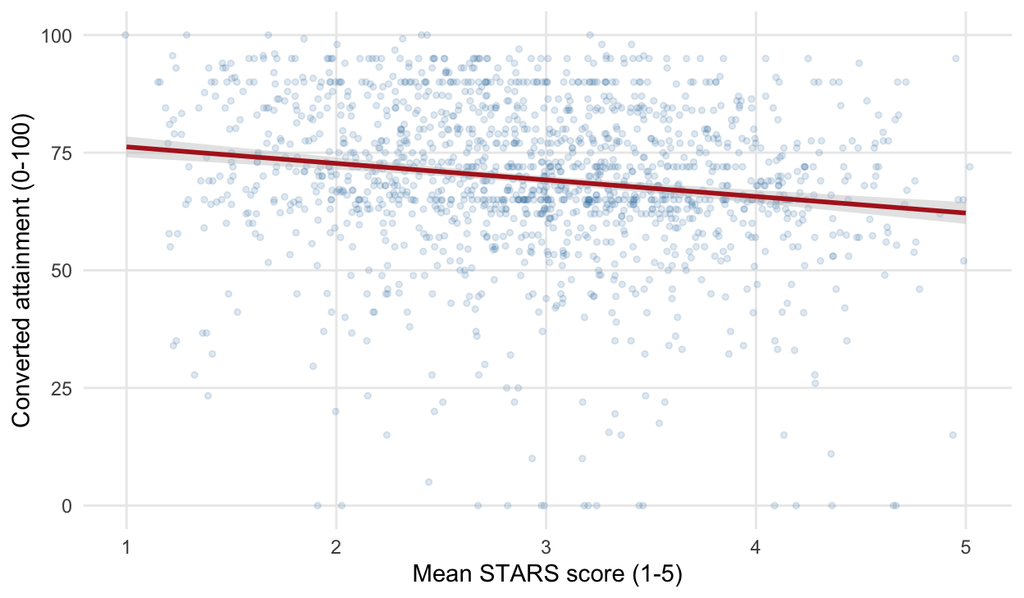

Figure 1. Unadjusted relationship between mean STARS score and converted academic attainment. The shaded band represents the 95% confidence interval for the fitted mean relationship.

An initial unadjusted regression estimated a 3.51-point decrease in converted attainment per one-point increase in STARS ($\beta=-3.514$). After introducing survey fixed effects, the coefficient decreased in absolute magnitude to $-3.152$, an attenuation of approximately 10%. This demonstrates that accounting for survey differences influenced the estimated relationship, although the negative association persisted.

To assess uncertainty in the survey-adjusted estimate, we calculated CR2 survey-clustered standard errors with Satterthwaite-adjusted degrees of freedom. This approach allows for heteroscedasticity and potential dependence between participants from the same survey, which conventional regression standard errors do not accommodate.

In the primary survey-adjusted model, a one-point increase in mean STARS score was associated with an estimated 3.15-point decrease in converted attainment ($\beta=-3.152$, CR2 95% CI $[-4.890,-1.414]$, $p=0.0027$). The confidence interval excludes zero, providing evidence of a negative association even after allowing for within-survey dependence.

The full regression explained approximately 28.4% of attainment variation ($R^2=0.284$). However, this includes variation explained by survey fixed effects and should not be attributed entirely to statistics anxiety. The partial $R^2$ for STARS was 0.0279, indicating that anxiety explained approximately 2.8% of the variation remaining after accounting for survey differences.

Thus, although the association was statistically significant, its explanatory contribution was modest. Statistical significance should not be confused with educational importance, particularly given the relatively large sample.

### Model diagnostics and sensitivity analyses

Regression diagnostics were examined to assess whether the fitted model adequately described the data. The residual-versus-fitted plot suggested non-constant residual variance, with greater dispersion at lower fitted attainment values. The normal Q-Q plot also revealed departures from normality, particularly in the tails, indicating unusually large residuals.

These findings motivated the comparison of conventional, HC3 and CR2 standard errors. The conventional standard error for STARS was 0.482, increasing slightly to 0.505 under HC3 and more substantially to 0.767 under CR2. The larger clustered standard error indicates that allowing for within-survey dependence materially affects the estimated precision of the coefficient. Nevertheless, the negative association remained statistically significant.

CR2 inference was preferred because it addresses heteroscedasticity and possible within-survey dependence, with a small-sample adjustment appropriate to the limited number of surveys. However, it does not correct for potential non-linearity, influential observations or other model misspecification.

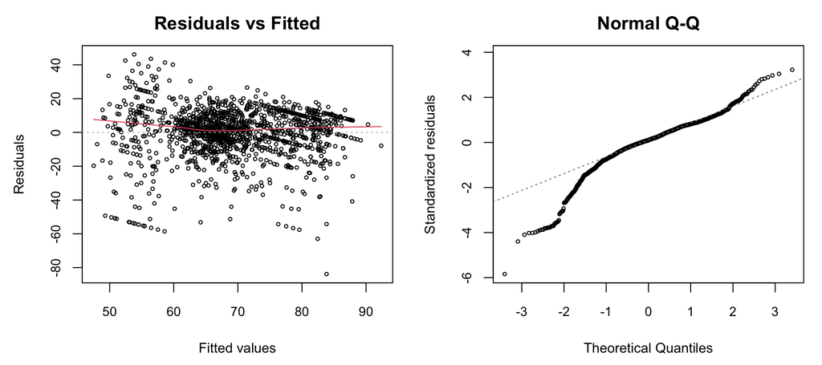

Diagnostic plots for the survey-adjusted regression: residuals versus fitted values (left) and normal Q-Q plot (right).

To investigate whether our findings depended on analytical decisions, we conducted sensitivity analyses involving grade conversion, questionnaire completeness, correlation method and influential observations.

The results are summarised in Table 1. Restricting the sample to numerical grades or complete anxiety questionnaires produced estimates close to the primary coefficient, suggesting that the association was relatively insensitive to these inclusion decisions. Spearman’s rank correlation was also negative ($\rho=-0.185$, $p<0.001$), indicating that the direction of the unadjusted relationship was not specific to Pearson’s correlation.

Table 1. Sensitivity of the survey-adjusted STARS coefficient to alternative analytical decisions.

| Analysis | N | STARS coefficient |
| --- | --- | --- |
| Primary analysis | 1509 | -3.152 |
| Numerical grades only | 1243 | -3.277 |
| Complete questionnaires | 1412 | -3.177 |
| Excluding Cook’s D flagged observations | 1414 | -2.685 |

Cook’s distance identified 95 observations, approximately 6.3% of the primary sample, exceeding the conventional screening threshold of $4/N$. Excluding these observations reduced the coefficient from $-3.152$ to $-2.685$, a 14.8% reduction in absolute magnitude. Although the negative direction remained unchanged, the result indicates some sensitivity to influential observations.

Importantly, Cook’s distance identifies potentially influential observations rather than necessarily erroneous data. We therefore retained all participants in the primary analysis and treated this exclusion as exploratory.

## Distinguishing statistics and mathematics anxiety

Although our primary analysis focuses on statistics anxiety, mathematics anxiety may also be associated with statistics attainment. Terry et al. (2023) highlight the possibility of a jangle fallacy, whereby differently named scales are incorrectly assumed to measure distinct psychological constructs. We therefore investigate whether statistics anxiety provides additional explanatory power beyond mathematics anxiety, using both the original and modified anxiety scales.

#### Correlations between anxiety measures

Pearson correlations between the four anxiety measures.

|  | STARS | R-MARS-S | STARS-M | R-MARS |
| --- | --- | --- | --- | --- |
| STARS | 1.000 | 0.848 | 0.865 | 0.760 |
| R-MARS-S | 0.848 | 1.000 | 0.781 | 0.826 |
| STARS-M | 0.865 | 0.781 | 1.000 | 0.841 |
| R-MARS | 0.760 | 0.826 | 0.841 | 1.000 |

All four anxiety measures exhibit strong positive correlations, ranging from 0.760 to 0.865. This suggests substantial overlap between statistics and mathematics anxiety, although high correlations alone are insufficient to establish that they measure the same underlying construct.

#### Separate and joint regression models

We initially fit separate linear regression models for each anxiety measure, controlling for survey-level differences. We subsequently include both statistics and mathematics anxiety within each scale family to investigate their conditional associations with attainment. As in the primary analysis, CR2 cluster-robust confidence intervals account for potential within-survey dependence.

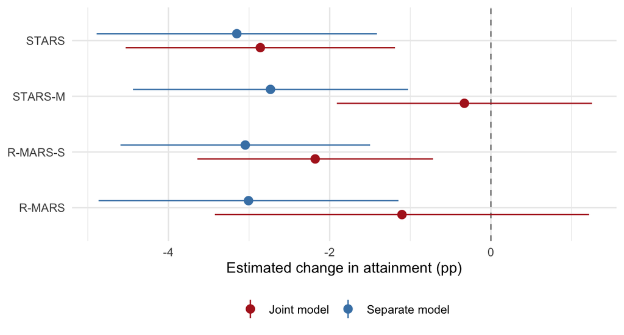

Estimated change in attainment per one-point increase in anxiety score, with cluster-robust 95% confidence intervals. All models adjust for survey effects.

As shown in Figure 3, all four anxiety measures were negatively associated with attainment when considered separately, with estimated coefficients ranging from −3.15 to −2.73 attainment points per one-point increase in anxiety.

After including both anxiety measures within each scale family, the statistics anxiety coefficients remained negative, at $-2.86$ for STARS and $-2.18$ for R-MARS-S, with both confidence intervals excluding zero. In contrast, the mathematics anxiety coefficients attenuated towards zero, with confidence intervals including zero.

These findings suggest that statistics anxiety retains an association with attainment after accounting for mathematics anxiety.

#### Comparison of explained variance

To investigate the additional explanatory power of each anxiety measure, we compare the proportion of variance explained ($R^2$) by models containing statistics anxiety, mathematics anxiety and both predictors. Survey effects and the analysis sample are held constant throughout.

Explained variance (%) and additional contributions (percentage points) of anxiety measures.

| Model | STARS | R-MARS |
| --- | --- | --- |
| Survey only | 26.35 | 26.35 |
| Survey + statistics anxiety | 28.41 | 28.48 |
| Survey + mathematics anxiety | 27.98 | 28.22 |
| Survey + both | 28.41 | 28.56 |
| Additional statistics anxiety | 0.43 | 0.34 |
| Additional mathematics anxiety | 0.01 | 0.08 |

Survey effects alone explain 26.35% of attainment variation. Statistics anxiety provides a greater additional contribution to explained variance than mathematics anxiety in both scale families (0.43 versus 0.01 percentage points for STARS and 0.34 versus 0.08 for R-MARS). However, these increases are modest, suggesting that much of the explanatory information is shared between the two anxiety measures.

#### Comparing regression coefficients

Although the statistics anxiety confidence intervals exclude zero in the joint models while the mathematics anxiety intervals do not, this does not necessarily establish a difference between the two coefficients. We therefore directly estimate the difference between the statistics and mathematics anxiety coefficients by reparameterising each joint model using the average and half-difference of the two anxiety scores.

Statistics minus mathematics anxiety coefficients, with cluster-robust 95% confidence intervals.

| Scale family | Difference | Lower CI | Upper CI | p-value |
| --- | --- | --- | --- | --- |
| STARS family | -2.531 | -5.206 | 0.143 | 0.061 |
| R-MARS family | -1.076 | -4.456 | 2.304 | 0.477 |

The estimated differences are negative in both scale families, indicating stronger estimated negative associations for statistics anxiety per one-point increase in the measured score. However, both confidence intervals include zero. Consequently, there is insufficient evidence to conclude that statistics anxiety has a stronger association with attainment than mathematics anxiety.

#### Multicollinearity

After accounting for survey differences, the correlations between statistics and mathematics anxiety remain high (0.864 and 0.828 for the STARS and R-MARS families, respectively). The corresponding variance inflation factors of 3.94 and 3.19 indicate that multicollinearity reduces the precision of the individual coefficient estimates. This limits our ability to distinguish their separate associations with attainment.

### Interpretation and limitations

Overall, higher statistics anxiety was associated with lower academic attainment, including after adjustment for survey differences. The relationship remained negative under the analytical alternatives examined, although its estimated magnitude was somewhat sensitive to influential observations. The small partial $R^2$ indicates that statistics anxiety accounted for only a modest proportion of the variation in attainment beyond survey differences.

The secondary analysis suggests that statistics anxiety provides additional explanatory information beyond mathematics anxiety, with consistent findings across both scale families. However, its incremental contribution to explained variance is modest, and direct coefficient comparisons provide insufficient evidence that statistics anxiety has a stronger association with attainment than mathematics anxiety.

Several limitations should be considered. Converting grades to a common 0–100 scale does not fully eliminate differences in grading standards or assessment difficulty across institutions. Survey fixed effects account for differences in baseline attainment but cannot address all individual-level confounding or guarantee that the converted grades are directly comparable.

Furthermore, the final analysis included only participants with usable attainment records and sufficiently complete anxiety responses, representing a relatively small subset of the original dataset. If grade availability or questionnaire completion was associated with anxiety or attainment, selection bias may have influenced the results.

The model also assumes a common linear relationship across surveys. Although CR2 inference provides more appropriate uncertainty estimates under heteroscedasticity and within-survey dependence, it does not eliminate possible model misspecification or measurement error.

The substantial overlap between anxiety measures also limits our ability to distinguish their individual associations with attainment. Furthermore, both scales may capture broader psychological constructs, such as general test anxiety, which were not explicitly accounted for in our models. Differences in questionnaire content and measurement reliability may also influence the estimated associations, complicating direct comparisons between the two constructs.

Finally, the observational nature of the data prevents causal conclusions. Higher anxiety might contribute to poorer attainment, poorer attainment might increase anxiety, or both could be influenced by other characteristics such as mathematical preparation, prior academic performance or educational experiences.

Consequently, our analysis provides evidence of a statistically significant but modest negative association between statistics anxiety and academic attainment, rather than demonstrating that statistics anxiety directly causes lower grades.

## Conclusion

Higher statistics anxiety was associated with lower academic attainment, even after accounting for survey differences and mathematics anxiety. The negative association was robust to the alternative analytical decisions examined, although its explanatory contribution was modest. While statistics anxiety provided additional explanatory information, there was insufficient evidence that its association with attainment was stronger than that of mathematics anxiety. Given the observational nature of the data, these findings should be interpreted as associations rather than causal effects.

## Appendix: R code

```r
knitr::opts_chunk$set(echo = TRUE)

library(tidyverse)
# Load the SMARVUS dataset
data_file <- "smarvus_complete_050524.csv"

# Download dataset only if it is not already saved
if (!file.exists(data_file)) {
  smarvus_raw <- read_csv("https://osf.io/download/a4zmv/")
  write_csv(smarvus_raw, data_file)
} else {
  smarvus_raw <- read_csv(data_file)
}

# Initial dataset inspection
data_summary <- tibble(
  Observations = nrow(smarvus_raw),
  Variables = ncol(smarvus_raw),
  Duplicate_rows = sum(duplicated(smarvus_raw)),
  Duplicate_IDs = sum(duplicated(smarvus_raw$unique_id)),
  Missing_IDs = sum(is.na(smarvus_raw$unique_id))
)

data_summary

# Participants with recorded grades
smarvus_grades <- smarvus_raw %>%
  filter(!is.na(grade), grade != "Not Available")

nrow(smarvus_grades)
# Compare grading systems across surveys
grade_summary <- smarvus_grades %>%
  group_by(country, survey_id, grade_low, grade_high) %>%
  summarise(
    n = n(),
    Example_grades = paste(head(unique(grade), 3),
                           collapse = ", "),
    .groups = "drop"
  ) %>%
  arrange(desc(n))

print(n=22, grade_summary)
# Institution-specific letter grade boundaries

grade_boundaries <- bind_rows(
  tibble(
    survey_id = "brawijaya",
    grade = c("A", "B+", "B", "C+", "C", "D+", "D", "E"),
    lower = c(80, 75, 69, 60, 55, 50, 44, 0),
    upper = c(100, 80, 75, 69, 60, 55, 50, 44)
  ),

  tibble(
    survey_id = "york_can",
    grade = c("A+", "A", "B+", "B", "C+", "C", "D+", "D", "E", "F"),
    lower = c(90, 80, 75, 70, 65, 60, 55, 50, 40, 0),
    upper = c(100, 89, 79, 74, 69, 64, 59, 54, 49, 39)
  ),

  tibble(
    survey_id = "mef",
    grade = c("A", "A-", "B+", "B", "B-", "C+", "C", "C-", "D+", "D", "F"),
    lower = c(90, 80, 75, 70, 65, 60, 55, 50, 45, 35, 0),
    upper = c(100, 89, 79, 74, 69, 64, 59, 54, 49, 44, 35)
  ),

  tibble(
    survey_id = "limerick",
    grade = c("A1", "A2", "B1", "B2", "B3", "C1", "C2", "C3", "D1", "D2", "F"),
    lower = c(80, 75, 70, 65, 60, 55, 50, 45, 40, 35, 0),
    upper = c(100, 79, 74, 69, 64, 59, 54, 49, 44, 39, 35)
  )
) %>%
  mutate(
    grade_midpoint = (lower + upper) / 2
  )

stopifnot(!anyDuplicated(grade_boundaries[c("survey_id", "grade")]))


# Prepare numerical grades
smarvus_prepared <- smarvus_raw %>%
  mutate(

    grade_clean = str_trim(grade),

    # Convert numbers stored as text
    grade_num = suppressWarnings(as.numeric(str_remove(grade_clean, "%$"))),
    grade_low_num = suppressWarnings(as.numeric(grade_low)),
    grade_high_num = suppressWarnings(as.numeric(grade_high)),

    # Identify supported numerical grading systems
    supported_numeric =
      (grade_low_num == 0 & grade_high_num %in% c(10, 20, 100)) |
      (grade_low_num == 1 & grade_high_num == 10),

    # Check that marks are within their grading range
    valid_numeric =
      supported_numeric &
      !is.na(grade_num) &
      grade_num >= grade_low_num &
      grade_num <= grade_high_num) %>%

  # Add letter-grade midpoint conversions
  left_join(
    grade_boundaries %>%
      select(survey_id, grade, grade_midpoint),
    by = c("survey_id", "grade_clean" = "grade")) %>%

  # Create a single attainment variable
  mutate(
    grade_scaled = coalesce(
      if_else(valid_numeric,
        100 * (grade_num - grade_low_num) / (grade_high_num - grade_low_num),
        NA_real_),
      grade_midpoint),

    grade_method = case_when(
      !is.na(grade_midpoint) ~ "Letter grade midpoint",
      !is.na(grade_scaled) ~ "Numerical conversion",
      TRUE ~ "Unresolved or unavailable"))

# Check conversion results
smarvus_prepared %>%
  filter(!is.na(grade_clean), grade_clean != "Not Available") %>%
  count(grade_method)
# Inspect observations without a usable converted grade
smarvus_prepared %>%
  filter(
    !is.na(grade_clean),
    grade_clean != "Not Available",
    is.na(grade_scaled)
  ) %>%

  count(survey_id, grade_clean, sort = TRUE)
# Attention check variables
check_cols <- c(
  "Q7.1_24",
  "Q8.1_21",
  "Q9.1_22",
  "Q11.1_9",
  "Q13.1_17",
  "Q15.1_9"
)

# Count checks answered
smarvus_prepared$n_checks_answered <-
  rowSums(!is.na(smarvus_prepared[, check_cols]))

# Count incorrect responses to answered checks
smarvus_prepared <- smarvus_prepared %>%
  mutate(
    n_checks_failed =
      as.integer(!is.na(Q7.1_24) & Q7.1_24 != 1) +
      as.integer(!is.na(Q8.1_21) & Q8.1_21 != 5) +
      as.integer(!is.na(Q9.1_22) & Q9.1_22 != 1) +
      as.integer(!is.na(Q11.1_9) & Q11.1_9 != 3) +
      as.integer(!is.na(Q13.1_17) & Q13.1_17 != 2) +
      as.integer(!is.na(Q15.1_9) & Q15.1_9 != 4)
  )

# Summarise attention check results for usable grades
smarvus_prepared %>%
  filter(!is.na(grade_scaled)) %>%
  count(n_checks_answered, n_checks_failed)

# Participants with usable attainment
valid_grades <- smarvus_prepared %>%
  filter(!is.na(grade_scaled))

# Exclude explicit amnesty refusals
amnesty_passed <- valid_grades %>%
  filter(
    is.na(attention_amnesty) |
      attention_amnesty != "No")

# Exclude incorrect answered attention checks
smarvus_clean <- amnesty_passed %>%
  filter(n_checks_failed == 0)
exclusion_flow <- tibble(
  Stage = c(
    "Original dataset",
    "Non-missing grade entries",
    "Usable standardised attainment",
    "After attention amnesty",
    "After attention checks"
  ),

  N = c(
    nrow(smarvus_raw),
    nrow(smarvus_grades),
    nrow(valid_grades),
    nrow(amnesty_passed),
    nrow(smarvus_clean)
  )
) %>%
  mutate(
    Excluded = lag(N) - N
  )

knitr::kable(exclusion_flow)
stopifnot(
  !anyNA(smarvus_clean$grade_scaled),
  all(is.finite(smarvus_clean$grade_scaled)),
  all(smarvus_clean$grade_scaled >= 0),
  all(smarvus_clean$grade_scaled <= 100),
  all(smarvus_clean$n_checks_failed == 0),
  n_distinct(smarvus_clean$unique_id) == nrow(smarvus_clean)
)

write_csv(smarvus_clean, "smarvus_clean.csv")
write_csv(exclusion_flow, "exclusion_flow.csv")
# Pull out the item columns for each of the four anxiety scales
stars_items   <- smarvus_clean %>% select(Q7.1_1:Q7.1_23)
rmars_s_items <- smarvus_clean %>% select(Q7.2_1:Q7.2_23)
stars_m_items <- smarvus_clean %>% select(Q8.1_1:Q8.1_20)
rmars_items   <- smarvus_clean %>% select(Q8.2_1:Q8.2_24)
```

```r
stars_na   <- rowSums(is.na(stars_items))
rmars_s_na <- rowSums(is.na(rmars_s_items))
stars_m_na <- rowSums(is.na(stars_m_items))
rmars_na   <- rowSums(is.na(rmars_items))


missing_summary <- tibble(
  Scale = c("STARS", "RMARS-S", "STARS-M", "RMARS"),
  Items = c(ncol(stars_items), ncol(rmars_s_items), ncol(stars_m_items), ncol(rmars_items)),
  Complete_N = c(sum(stars_na == 0), sum(rmars_s_na == 0), sum(stars_m_na == 0), sum(rmars_na == 0)),
  Partial_Missing_N = c(
    sum(stars_na > 0 & stars_na < 23),
    sum(rmars_s_na > 0 & rmars_s_na < 23),
    sum(stars_m_na > 0 & stars_m_na < 20),
    sum(rmars_na > 0 & rmars_na < 24)
  ),
  All_Missing_N = c(sum(stars_na == 23), sum(rmars_s_na == 23), sum(stars_m_na == 20), sum(rmars_na == 24)),
  Min = c(
    min(stars_items, na.rm = TRUE),
    min(rmars_s_items, na.rm = TRUE),
    min(stars_m_items, na.rm = TRUE),
    min(rmars_items, na.rm = TRUE)
  ),
  Max = c(
    max(stars_items, na.rm = TRUE),
    max(rmars_s_items, na.rm = TRUE),
    max(stars_m_items, na.rm = TRUE),
    max(rmars_items, na.rm = TRUE)
  )
)

knitr::kable(
  missing_summary,
  col.names = c("Scale", "Number of Questions", "Complete sets of answers", "Partially Missing", "All Missing", "Min", "Max"),
  caption = "NA's and observed response range for each anxiety scale."
)


partial_data <- tibble(
  `STARS`   = stars_na,
  `RMARS-S` = rmars_s_na,
  `STARS-M` = stars_m_na,
  `RMARS`   = rmars_na
) %>%
  pivot_longer(everything(), names_to = "Scale", values_to = "Missing_Items") %>%
  filter(
    Missing_Items > 0,
    !(Scale == "STARS"   & Missing_Items == 23),
    !(Scale == "RMARS-S" & Missing_Items == 23),
    !(Scale == "STARS-M" & Missing_Items == 20),
    !(Scale == "RMARS"   & Missing_Items == 24)
  )

ggplot(partial_data, aes(x = factor(Missing_Items))) +
  geom_bar(fill = "steelblue") +
  facet_wrap(~ Scale, scales = "free_x") +
  labs(
    title = "Items Skipped by Partially Missing Participants",
    x = "Number of Missing Items",
    y = "Number of Participants"
  ) +
  theme_minimal()

# Find which universities have participants missing exactly 4 items on RMARS-S and RMARS
rmarss_4_unis <- smarvus_clean %>%
  mutate(rmars_s_na = rmars_s_na) %>%
  filter(rmars_s_na == 4) %>%
  count(university, sort = TRUE)

rmars_4_unis <- smarvus_clean %>%
  mutate(rmars_na = rmars_na) %>%
  filter(rmars_na == 4) %>%
  count(university, sort = TRUE)

spike_uni     <- rmarss_4_unis %>% slice(1) %>% pull(university)
n_spike_uni   <- sum(smarvus_clean$university == spike_uni, na.rm = TRUE)
spike_rmarss  <- rmarss_4_unis %>% slice(1) %>% pull(n)
spike_rmars   <- rmars_4_unis %>% slice(1) %>% pull(n)
n_clean       <- nrow(smarvus_clean)

# which specific questions have the most missing values on each scale
top_missing_rmarss <- colSums(is.na(rmars_s_items)) %>% sort(decreasing = TRUE) %>% head(6)
top_missing_rmars  <- colSums(is.na(rmars_items)) %>% sort(decreasing = TRUE) %>% head(6)

# 3. Find the 4 questions with the most missing values on each scale
top4_rmarss <- colSums(is.na(rmars_s_items)) %>% sort(decreasing = TRUE) %>% head(4) %>% names()
top4_rmars  <- colSums(is.na(rmars_items))   %>% sort(decreasing = TRUE) %>% head(4) %>% names()

# Confirm whether any student at that university answered those 4 questions
spike_uni_data <- smarvus_clean %>%
  filter(university == spike_uni)

rmarss_top4_answered <- sum(!is.na(spike_uni_data %>% select(all_of(top4_rmarss))))
rmars_top4_answered  <- sum(!is.na(spike_uni_data %>% select(all_of(top4_rmars))))
# Compute mean scores using the 80% completion threshold
smarvus_scores_80_all <- smarvus_clean %>%
  mutate(
    stars_n   = rowSums(!is.na(select(., Q7.1_1:Q7.1_23))),
    rmars_s_n = rowSums(!is.na(select(., Q7.2_1:Q7.2_23))),
    stars_m_n = rowSums(!is.na(select(., Q8.1_1:Q8.1_20))),
    rmars_n   = rowSums(!is.na(select(., Q8.2_1:Q8.2_24))),

    stars_mean   = if_else(stars_n   >= 0.8 * 23, rowMeans(select(., Q7.1_1:Q7.1_23), na.rm = TRUE), NA_real_),
    rmars_s_mean = if_else(rmars_s_n >= 0.8 * 23, rowMeans(select(., Q7.2_1:Q7.2_23), na.rm = TRUE), NA_real_),
    stars_m_mean = if_else(stars_m_n >= 0.8 * 20, rowMeans(select(., Q8.1_1:Q8.1_20), na.rm = TRUE), NA_real_),
    rmars_mean   = if_else(rmars_n   >= 0.8 * 24, rowMeans(select(., Q8.2_1:Q8.2_24), na.rm = TRUE), NA_real_)
  )

desc_option_1 <- smarvus_scores_80_all %>%
  select(stars_mean, rmars_s_mean, stars_m_mean, rmars_mean) %>%
  pivot_longer(everything(), names_to = "Scale", values_to = "Score") %>%
  mutate(
    Scale = recode(
      Scale,
      stars_mean   = "STARS",
      rmars_s_mean = "RMARS-S",
      stars_m_mean = "STARS-M",
      rmars_mean   = "RMARS"
    )
  ) %>%
  group_by(Scale) %>%
  summarise(
    Valid_N     = sum(!is.na(Score)),
    Missing_N   = sum(is.na(Score)),
    Missing_Pct = round(mean(is.na(Score)) * 100, 1),
    Mean        = round(mean(Score, na.rm = TRUE), 2),
    SD          = round(sd(Score, na.rm = TRUE), 2),
    Min         = round(min(Score, na.rm = TRUE), 2),
    Max         = round(max(Score, na.rm = TRUE), 2),
    .groups = "drop"
  )


smarvus_scored_80 <- smarvus_scores_80_all %>%
  filter(!is.na(stars_mean), !is.na(rmars_s_mean), !is.na(stars_m_mean), !is.na(rmars_mean))

n_scored_80   <- nrow(smarvus_scored_80)
n_excluded_80 <- n_clean - n_scored_80


# Construct strict 100% complete-case dataset for sensitivity analysis
smarvus_scored_complete <- smarvus_clean %>%
  mutate(
    stars_n   = rowSums(!is.na(select(., Q7.1_1:Q7.1_23))),
    rmars_s_n = rowSums(!is.na(select(., Q7.2_1:Q7.2_23))),
    stars_m_n = rowSums(!is.na(select(., Q8.1_1:Q8.1_20))),
    rmars_n   = rowSums(!is.na(select(., Q8.2_1:Q8.2_24))),

    stars_mean   = if_else(stars_n   == 23, rowMeans(select(., Q7.1_1:Q7.1_23)), NA_real_),
    rmars_s_mean = if_else(rmars_s_n == 23, rowMeans(select(., Q7.2_1:Q7.2_23)), NA_real_),
    stars_m_mean = if_else(stars_m_n == 20, rowMeans(select(., Q8.1_1:Q8.1_20)), NA_real_),
    rmars_mean   = if_else(rmars_n   == 24, rowMeans(select(., Q8.2_1:Q8.2_24)), NA_real_)
  ) %>%
  filter(!is.na(stars_mean), !is.na(rmars_s_mean), !is.na(stars_m_mean), !is.na(rmars_mean))
```

```r
n_scored_complete   <- nrow(smarvus_scored_complete)
n_excluded_complete <- n_clean - n_scored_complete
knitr::kable(
  desc_option_1,
  col.names = c("Scale", "Valid (N)", "Missing (N)", "Missing (%)", "Mean", "SD", "Min", "Max"),
  caption = "Descriptive statistics for the four anxiety scales under the 80% completion threshold (evaluated on N = 1,542)."
)

# (Uses smarvus_scored_80; swap to smarvus_scored_complete if Option 2 is chosen)
smarvus_scored_80 %>%
  select(stars_mean, rmars_s_mean, stars_m_mean, rmars_mean) %>%
  pivot_longer(everything(), names_to = "Scale", values_to = "Score") %>%
  mutate(
    Scale = recode(
      Scale,
      stars_mean   = "STARS (Statistics)",
      rmars_s_mean = "RMARS-S (Statistics)",
      stars_m_mean = "STARS-M (Mathematics)",
      rmars_mean   = "RMARS (Mathematics)"
    )
  ) %>%
  ggplot(aes(x = Score)) +
  geom_histogram(binwidth = 0.25, fill = "steelblue", colour = "white") +
  facet_wrap(~ Scale) +
  labs(
    title = "Distribution of Mean Anxiety Scores Across the Four Scales",
    x = "Mean Score (1-5)",
    y = "Number of Participants"
  ) +
  theme_minimal()
library(clubSandwich)
library(sandwich)
library(lmtest)

# Common analysis sample
analysis_data <- smarvus_scored_80

# Check sample characteristics
analysis_summary <- analysis_data %>%
  summarise(
    N = n(),
    Missing_grades = sum(is.na(grade_scaled)),
    Missing_STARS = sum(is.na(stars_mean)),
    Surveys = n_distinct(survey_id)
  )

# Pearson correlation
stars_cor <- cor.test(
  ~ stars_mean + grade_scaled,
  data = analysis_data,
  method = "pearson"
)

# Exploratory unadjusted regression
model_unadjusted <- lm(
  grade_scaled ~ stars_mean,
  data = analysis_data
)

# Primary survey-adjusted regression
model_adjusted <- lm(
  grade_scaled ~ stars_mean + factor(survey_id),
  data = analysis_data
)

# Survey-only model
model_institution <- lm(
  grade_scaled ~ factor(survey_id),
  data = analysis_data
)

# Compare the two regression estimates
regression_comparison <- tibble(
  Model = c("Unadjusted", "Survey-adjusted"),
  N = c(
    nobs(model_unadjusted),
    nobs(model_adjusted)
  ),
  Coefficient = c(
    unname(coef(model_unadjusted)["stars_mean"]),
    unname(coef(model_adjusted)["stars_mean"])
  ),
  R_squared = c(
    summary(model_unadjusted)$r.squared,
    summary(model_adjusted)$r.squared
  )
)

# Additional explanatory contribution of STARS
model_comparison <- anova(
  model_institution,
  model_adjusted
)

# Partial R-squared
r2_reduced <- summary(model_institution)$r.squared
r2_full <- summary(model_adjusted)$r.squared

partial_r2 <- (r2_full - r2_reduced) /
  (1 - r2_reduced)
ggplot(
  analysis_data,
  aes(x = stars_mean, y = grade_scaled)
) +
  geom_point(
    alpha = 0.16,
    size = 1,
    colour = "steelblue",
    position = position_jitter(
      width = 0.025,
      height = 0,
      seed = 10108
    )
  ) +
  geom_smooth(
    method = "lm",
    formula = y ~ x,
    se = TRUE,
    colour = "firebrick",
    fill = "grey75"
  ) +
  labs(
    x = "Mean STARS score (1-5)",
    y = "Converted attainment (0-100)"
  ) +
  theme_minimal(base_size = 11) +
  theme(
    panel.grid.minor = element_blank()
  )
# Conventional inference
conventional_result <- summary(
  model_adjusted
)$coefficients["stars_mean", ]

# HC3 heteroscedasticity-robust inference
hc3_result <- lmtest::coeftest(
  model_adjusted,
  vcov. = sandwich::vcovHC(
    model_adjusted,
    type = "HC3"
  )
)["stars_mean", ]

# CR2 survey-clustered inference
cluster_test <- clubSandwich::coef_test(
  model_adjusted,
  vcov = "CR2",
  cluster = analysis_data$survey_id,
  test = "Satterthwaite"
)

stars_cr2 <- cluster_test[
  cluster_test$Coef == "stars_mean",
]

# Extract coefficient and uncertainty estimates
beta <- stars_cr2$beta
se <- stars_cr2$SE
df_satt <- stars_cr2$df_Satt
p_cr2 <- stars_cr2$p_Satt

# CR2 95% confidence interval
ci <- beta + c(-1, 1) *
  qt(0.975, df = df_satt) * se

# Compare standard-error estimators
se_comparison <- tibble(
  Method = c(
    "Conventional OLS",
    "HC3 robust",
    "CR2 survey-clustered"
  ),
  Standard_error = c(
    conventional_result["Std. Error"],
    hc3_result["Std. Error"],
    se
  )
)
# Save existing graphical settings
old_par <- par(no.readonly = TRUE)

# Arrange plots side by side
par(
  mfrow = c(1, 2),
  mar = c(4.5, 4.5, 2.5, 1),
  cex.axis = 0.85,
  cex.lab = 0.9
)

# Residuals versus fitted values
plot(
  model_adjusted,
  which = 1,
  main = "Residuals vs Fitted",
  sub.caption = "",
  caption = "",
  cex = 0.5,
  id.n = 0
)

# Normal Q-Q plot
plot(
  model_adjusted,
  which = 2,
  main = "Normal Q-Q",
  sub.caption = "",
  caption = "",
  cex = 0.5,
  id.n = 0
)

# Restore graphical settings
par(old_par)
# Sensitivity 1: Numerical grades only
numeric_data <- analysis_data %>%
  filter(grade_method == "Numerical conversion")

model_numeric <- lm(
  grade_scaled ~ stars_mean + factor(survey_id),
  data = numeric_data
)

# Sensitivity 2: Complete anxiety questionnaires
complete_data <- smarvus_scored_complete

model_complete <- lm(
  grade_scaled ~ stars_mean + factor(survey_id),
  data = complete_data
)

# Sensitivity 3: Spearman rank correlation
spearman_result <- cor.test(
  analysis_data$stars_mean,
  analysis_data$grade_scaled,
  method = "spearman",
  exact = FALSE
)

# Sensitivity 4: Influence diagnostics
cooks_d <- cooks.distance(model_adjusted)

# Conventional screening threshold
cooks_threshold <- 4 / nrow(analysis_data)

# Number of potentially influential observations
n_influential <- sum(
  cooks_d > cooks_threshold
)

# Inspect the most influential observations
influence_summary <- analysis_data %>%
  mutate(
    observation = row_number(),
    cooks_d = cooks_d
  ) %>%
  arrange(desc(cooks_d)) %>%
  select(
    observation,
    survey_id,
    grade_scaled,
    stars_mean,
    cooks_d
  ) %>%
  slice_head(n = 10)

# Retain Cook's distance plot as hidden exploration
# (Not displayed in the final PDF)

# Exclude flagged observations for sensitivity analysis only
analysis_no_influential <- analysis_data[
  cooks_d <= cooks_threshold,
]
```

```r
model_no_influential <- lm(
  grade_scaled ~ stars_mean + factor(survey_id),
  data = analysis_no_influential
)

# Compare all survey-adjusted coefficients
sensitivity_table <- tibble(
  Analysis = c(
    "Primary analysis",
    "Numerical grades only",
    "Complete questionnaires",
    "Excluding Cook's D flagged observations"
  ),
  N = c(
    nrow(analysis_data),
    nrow(numeric_data),
    nrow(complete_data),
    nrow(analysis_no_influential)
  ),
  Coefficient = c(
    unname(coef(model_adjusted)["stars_mean"]),
    unname(coef(model_numeric)["stars_mean"]),
    unname(coef(model_complete)["stars_mean"]),
    unname(coef(model_no_influential)["stars_mean"])
  )
)
knitr::kable(
  sensitivity_table,
  digits = 3,
  col.names = c(
    "Analysis",
    "N",
    "STARS coefficient"
  ),
  caption = "Table 1. Sensitivity of the survey-adjusted STARS coefficient to alternative analytical decisions."
)
anxiety_cor <- analysis_data %>%
  select(
    STARS = stars_mean,
    `R-MARS-S` = rmars_s_mean,
    `STARS-M` = stars_m_mean,
    `R-MARS` = rmars_mean
  ) %>%
  cor(method = "pearson")

knitr::kable(
  round(anxiety_cor, 3),
  caption = "Pearson correlations between the four anxiety measures."
)
anxiety_vars <- c(
  "STARS" = "stars_mean",
  "R-MARS-S" = "rmars_s_mean",
  "STARS-M" = "stars_m_mean",
  "R-MARS" = "rmars_mean"
)

anxiety_comparison <- purrr::imap_dfr(
  anxiety_vars, function(variable, scale) {

    model <- lm(
      reformulate(c(variable, "factor(survey_id)"),
                  response = "grade_scaled"),
      data = analysis_data
    )

    result <- clubSandwich::coef_test(
      model,
      vcov = "CR2",
      cluster = analysis_data$survey_id,
      test = "Satterthwaite"
    )

    result <- result[result$Coef == variable, ]

    tibble(
      Scale = scale,
      N = nobs(model),
      Coefficient = result$beta,
      Lower_CI = result$beta -
        qt(0.975, result$df_Satt) * result$SE,
      Upper_CI = result$beta +
        qt(0.975, result$df_Satt) * result$SE,
      P_value = result$p_Satt
    )
  }
)
model_stars_joint <- lm(
  grade_scaled ~ stars_mean + stars_m_mean +
    factor(survey_id),
  data = analysis_data
)

model_rmars_joint <- lm(
  grade_scaled ~ rmars_s_mean + rmars_mean +
    factor(survey_id),
  data = analysis_data
)
extract_cluster_results <- function(model, variables, label) {

  result <- clubSandwich::coef_test(
    model,
    vcov = "CR2",
    cluster = analysis_data$survey_id,
    test = "Satterthwaite"
  )

  result <- result[result$Coef %in% variables, ]

  tibble(
    Model = label,
    Predictor = result$Coef,
    Coefficient = result$beta,
    Lower_CI = result$beta -
      qt(0.975, result$df_Satt) * result$SE,
    Upper_CI = result$beta +
      qt(0.975, result$df_Satt) * result$SE,
    P_value = result$p_Satt
  )
}

joint_results <- bind_rows(
  extract_cluster_results(
    model_stars_joint,
    c("stars_mean", "stars_m_mean"),
    "STARS family"
  ),
  extract_cluster_results(
    model_rmars_joint,
    c("rmars_s_mean", "rmars_mean"),
    "R-MARS family"
  )
)
plot_separate <- anxiety_comparison %>%
  mutate(Adjustment = "Separate model")

plot_joint <- joint_results %>%
  mutate(
    Scale = recode(
      Predictor,
      stars_mean = "STARS",
      rmars_s_mean = "R-MARS-S",
      stars_m_mean = "STARS-M",
      rmars_mean = "R-MARS"
    ),
    Adjustment = "Joint model"
  )

coefficient_data <- bind_rows(plot_separate, plot_joint) %>%
  mutate(
    Scale = factor(
      Scale,
      levels = c("R-MARS", "R-MARS-S", "STARS-M", "STARS")
    )
  )

ggplot(coefficient_data,
       aes(x = Scale, y = Coefficient, colour = Adjustment)) +
  geom_hline(yintercept = 0, linetype = "dashed",
             colour = "grey50") +
  geom_pointrange(
    aes(ymin = Lower_CI, ymax = Upper_CI),
    position = position_dodge(width = 0.5)
  ) +
  coord_flip() +
  scale_colour_manual(values = c(
    "Separate model" = "steelblue",
    "Joint model" = "firebrick"
  )) +
  labs(
    x = NULL,
    y = "Estimated change in attainment (pp)",
    colour = NULL
  ) +
  theme_minimal() +
  theme(legend.position = "bottom")
compare_r2 <- function(stats_var, maths_var) {

  survey_model <- lm(
    grade_scaled ~ factor(survey_id),
    data = analysis_data
  )

  stats_model <- lm(
    reformulate(c(stats_var, "factor(survey_id)"),
                response = "grade_scaled"),
    data = analysis_data
  )

  maths_model <- lm(
    reformulate(c(maths_var, "factor(survey_id)"),
                response = "grade_scaled"),
    data = analysis_data
  )

  joint_model <- lm(
    reformulate(c(stats_var, maths_var,
                  "factor(survey_id)"),
                response = "grade_scaled"),
    data = analysis_data
  )

  stopifnot(
    all(c(nobs(survey_model), nobs(stats_model),
          nobs(maths_model), nobs(joint_model)) ==
          nrow(analysis_data))
  )

  r2_survey <- summary(survey_model)$r.squared
  r2_stats <- summary(stats_model)$r.squared
  r2_maths <- summary(maths_model)$r.squared
  r2_joint <- summary(joint_model)$r.squared

  100 * c(
    r2_survey,
    r2_stats,
    r2_maths,
    r2_joint,
    r2_joint - r2_maths,
    r2_joint - r2_stats
  )
}

r2_comparison <- data.frame(
  Model = c(
    "Survey only",
    "Survey + statistics anxiety",
    "Survey + mathematics anxiety",
    "Survey + both",
    "Additional statistics anxiety",
    "Additional mathematics anxiety"
  ),
  STARS = compare_r2("stars_mean", "stars_m_mean"),
  `R-MARS` = compare_r2("rmars_s_mean", "rmars_mean"),
  check.names = FALSE
)

knitr::kable(
  r2_comparison,
  digits = 2,
  caption = "Explained variance (%) and additional contributions (percentage points) of anxiety measures."
)
contrast_data <- analysis_data %>%
  mutate(
    stars_average = (stars_mean + stars_m_mean) / 2,
    stars_difference = (stars_mean - stars_m_mean) / 2,
    rmars_average = (rmars_s_mean + rmars_mean) / 2,
    rmars_difference = (rmars_s_mean - rmars_mean) / 2
  )

model_stars_contrast <- lm(
  grade_scaled ~ stars_average + stars_difference +
    factor(survey_id),
  data = contrast_data
)
```

```r
model_rmars_contrast <- lm(
  grade_scaled ~ rmars_average + rmars_difference +
    factor(survey_id),
  data = contrast_data
)

contrast_results <- bind_rows(
  extract_cluster_results(
    model_stars_contrast,
    "stars_difference",
    "STARS family"
  ),
  extract_cluster_results(
    model_rmars_contrast,
    "rmars_difference",
    "R-MARS family"
  )
) %>%
  select(-Predictor)

knitr::kable(
  contrast_results,
  digits = 3,
  col.names = c("Scale family", "Difference",
                "Lower CI", "Upper CI", "p-value"),
  caption = "Statistics minus mathematics anxiety coefficients, with cluster-robust 95% confidence intervals."
)
anxiety_within <- analysis_data %>%
  group_by(survey_id) %>%
  mutate(across(
    c(stars_mean, stars_m_mean, rmars_s_mean, rmars_mean),
    ~ .x - mean(.x)
  )) %>%
  ungroup()

r_stars <- cor(
  anxiety_within$stars_mean,
  anxiety_within$stars_m_mean
)

r_rmars <- cor(
  anxiety_within$rmars_s_mean,
  anxiety_within$rmars_mean
)

vif_results <- tibble(
  Model = c("STARS family", "R-MARS family"),
  Within_survey_r = c(r_stars, r_rmars),
  VIF = 1 / (1 - Within_survey_r^2)
)
```